# ATP Match Analysis - 2023

## Introduction

Players all throughout the world engage in a wide variety of sports and games. It is well acknowledged that sports and competitions are crucial to the development of human resources. Sports no longer refers to pure play, which is a spontaneous activity in which the source of enjoyment is participation rather than the result. Actively participating in competitive sports helps to develop both a healthy body and mind. Players need to have a competitive streak and yet at the same time, it is important to handle losses in the right manner too. True sportspersons do not believe in quitting, they will fight until their last breath to make sure that they have it in them to handle the different adversities. There are a lot of case studies of various players and a team that battled the adversities and came out on top. There was a need to prepare the players mentally too. This inchoates a new era of analysis by crunching the data, which will alleviate the player’s mentality and wisdom towards their respective game.

Over the years, a variety of data-capturing devices and technologies, have become available in the sports industry. These innovations paved the way for the sports industry to influence those data with analytics. So, those studies suggest a data-driven way of approach to both on-field and off-field analytics. Sports analytics is a field that applies data analysis technologies to analyze various components of the sports industry, such as player performance, business performance, tackling the game in different ways, recruitment, and more

## Summary

In recent years, the trending words ‘Big Data’ and ’Analytics’ heard in each and every field of study, especially in the applications and conjoining the terms with fields like Finance Analytics, Business Analytics, Risk Analytics, Data Analytics, and so on. In such a way, sports have also taken their journey, to have a scientific way of studying and analyzing the nature of tackling the game by the players’ performance and started using the new digital technological tools to bring out a lane with ‘Analytical View’, known to be “Sports Analytics.

Sports are associated with numerous games having huge amounts of information based on the past, which cannot be analyzed in a meaningful way. In this data tech world, due to expansion and innovation, social media shows the player's performance of the game in each and every angle that has inflated everyone from players to the viewers in and around 360 degrees. This article offers a pristine view of the exploration of statistical analysis in the emerging field of sports through analytics. The state of this study is to get a clear picture of Statistics and its subfields in the area of sports. This discussion also paves the way for the intensification of Sports and Analytics (especially a Statistician) to integrate the interdisciplinary approach in the upcoming decade and also view the screen behind the magic of sports analytics. So let's inchoate an overview of Sports Analytics with Statistics.

## WHY ATP ANALYSIS?

ATP tennis analytics, which involves the collection and analysis of data related to professional tennis matches and players on the ATP Tour (Association of Tennis Professionals), offer several benefits and serve various purposes:

- ATP tennis analytics allow coaches and players to assess performance metrics such as serve speed, accuracy, shot placement, and movement patterns. This information helps players identify strengths and weaknesses, leading to targeted training and strategic adjustments.
- For strategic development, Coaches and players can use data analytics to develop and refine game strategies. By analyzing opponents' playing styles and tendencies, they can devise game plans to exploit weaknesses and maximize their own strengths.
- Injury Prevention Monitoring player movement patterns and physical exertion through analytics can help in injury prevention. Coaches and trainers can identify signs of fatigue or overexertion and adjust training regimens accordingly.
- Scouting Opponents Players and coaches can use analytics to scout upcoming opponents. By studying historical performance data, they can gain insights into opponents' preferred shots, court positioning, and strategies, aiding in match preparation.
- Post-match analysis using analytics allows players and coaches to review match performance in detail. They can study statistics on points won, errors made, and shot selection to make informed decisions for future matches.
- Tennis academies and development programs use analytics to identify promising young talent. By analyzing performance data, they can select players with the potential to excel in the sport and provide them with targeted training.
- ATP tennis analytics contribute to the fan experience by providing viewers with in-depth statistics and insights during broadcasts. Fans can gain a deeper understanding of players' performance and strategies, enhancing their enjoyment of the sport.
- Broadcasters use analytics to enhance their coverage of tennis matches. They can provide viewers with real-time data, such as serve speeds and rally statistics, to make matches more engaging and informative.

## Data set Description:

`Link for dataset :` https://github.com/JeffSackmann/tennis_atp

Our main focus was concentrating on the Post-match analysis of the ATP matches played across the globe in 2023 (till date). The dataset is collected from Jeff Sackman’s GitHub repository (tennis_atp/atp_matches_2023.csv).

- The data included the ATP player file, historical rankings, results, and match stats.
- The player file columns are player_id, first_name, last_name, hand, birth_date, country_code, height (cm).
- The columns for the ranking files are ranking_date, ranking, player_id, ranking_points (where available).
- There are up to three files per season: One for tour-level main draw matches (e.g. 'atp_matches_2023.csv')
- To make the results files easier for more people to use, the biographical and ranking files: each row contains several columns of biographical information, along with ranking and ranking points, for both players.
- Match Stats are included, which consisted (e.g. 1st serves in, not 1st serve percentage), from which traditional percentages can be calculated.

## Problem Solved in this Analysis :

We were interested in carrying out an exploratory data analysis with this data in order to gain primary insights into the analysis such as,

1. Which country had the most no of wins in the 2023 ATP tour (till date)?
2. Which player in the ATP circuit had the most no of wins in the tour of 2023 (till date)?
3. Which countries dominated (ie., had the most no wins ) on three different surfaces of the tennis court?
4. Is there any correlation between the first serves vs. the first serve points won?

```python
## importing the necessary libraries
import pandas as pd
import numpy as np
import plotly.express as px
import seaborn as sns
import matplotlib.pyplot as plt
import plotly.graph_objects as go
import plotly.io as pio
pio.renderers.default = 'png'
```

```python
## Loading the Dataset
df=pd.read_csv("atp_matches_2023.csv")
df
```

|  | tourney_id | tourney_name | surface | draw_size | tourney_level | tourney_date | match_num | winner_id | winner_seed | winner_entry | ... | l_1stIn | l_1stWon | l_2ndWon | l_SvGms | l_bpSaved | l_bpFaced | winner_rank | winner_rank_points | loser_rank | loser_rank_points |
| --- | --- | --- | --- | --- | --- | --- | --- | --- | --- | --- | --- | --- | --- | --- | --- | --- | --- | --- | --- | --- | --- |
| 0 | 2023-9900 | United Cup | Hard | 18 | A | 20230102 | 300 | 126203 | 3.0 | NaN | ... | 62.0 | 47.0 | 15.0 | 12.0 | 9.0 | 9.0 | 9.0 | 3355.0 | 16.0 | 2375.0 |
| 1 | 2023-9900 | United Cup | Hard | 18 | A | 20230102 | 299 | 126207 | NaN | NaN | ... | 12.0 | 8.0 | 3.0 | 4.0 | 1.0 | 3.0 | 19.0 | 2000.0 | 23.0 | 1865.0 |
| 2 | 2023-9900 | United Cup | Hard | 18 | A | 20230102 | 296 | 126203 | 3.0 | NaN | ... | 62.0 | 51.0 | 7.0 | 12.0 | 2.0 | 2.0 | 9.0 | 3355.0 | 10.0 | 2905.0 |
| 3 | 2023-9900 | United Cup | Hard | 18 | A | 20230102 | 295 | 126207 | NaN | NaN | ... | 41.0 | 26.0 | 12.0 | 9.0 | 6.0 | 9.0 | 19.0 | 2000.0 | 245.0 | 220.0 |
| 4 | 2023-9900 | United Cup | Hard | 18 | A | 20230102 | 292 | 126774 | 1.0 | NaN | ... | 58.0 | 48.0 | 18.0 | 16.0 | 1.0 | 2.0 | 4.0 | 5550.0 | 16.0 | 2375.0 |
| ... | ... | ... | ... | ... | ... | ... | ... | ... | ... | ... | ... | ... | ... | ... | ... | ... | ... | ... | ... | ... | ... |
| 2364 | 2023-M-DC-2023-WG2-PO-RSA-LUX-01 | Davis Cup WG2 PO: RSA vs LUX | Hard | 4 | D | 20230204 | 5 | 202335 | NaN | NaN | ... | NaN | NaN | NaN | NaN | NaN | NaN | NaN | NaN | 1717.0 | 1.0 |
| 2365 | 2023-M-DC-2023-WG2-PO-TUN-CYP-01 | Davis Cup WG2 PO: TUN vs CYP | Hard | 4 | D | 20230203 | 1 | 117365 | NaN | NaN | ... | NaN | NaN | NaN | NaN | NaN | NaN | 990.0 | 11.0 | 279.0 | 190.0 |
| 2366 | 2023-M-DC-2023-WG2-PO-TUN-CYP-01 | Davis Cup WG2 PO: TUN vs CYP | Hard | 4 | D | 20230203 | 2 | 121411 | NaN | NaN | ... | NaN | NaN | NaN | NaN | NaN | NaN | 364.0 | 131.0 | 894.0 | 15.0 |
| 2367 | 2023-M-DC-2023-WG2-PO-TUN-CYP-01 | Davis Cup WG2 PO: TUN vs CYP | Hard | 4 | D | 20230203 | 4 | 144949 | NaN | NaN | ... | NaN | NaN | NaN | NaN | NaN | NaN | 894.0 | 15.0 | 285.0 | 184.0 |
| 2368 | 2023-M-DC-2023-WG2-PO-TUN-CYP-01 | Davis Cup WG2 PO: TUN vs CYP | Hard | 4 | D | 20230203 | 5 | 121411 | NaN | NaN | ... | NaN | NaN | NaN | NaN | NaN | NaN | 364.0 | 131.0 | 990.0 | 11.0 |

2369 rows × 49 columns

#### (1) Most no_of_wins per_country

```python
## Finding the countries which have atleast 30 wins in total
x=df['winner_ioc'].value_counts().loc[lambda x:x>30].reset_index().rename(columns={"index":"Country",0:"count"})
## saving the rest of the countires as others
y=df['winner_ioc'].value_counts().loc[lambda x:x<=30].sum()
x.loc[len(x.index)]=['Others',y]
x
```

|  | winner_ioc | count |
| --- | --- | --- |
| 0 | USA | 315 |
| 1 | FRA | 183 |
| 2 | ESP | 173 |
| 3 | RUS | 168 |
| 4 | ITA | 154 |
| 5 | AUS | 152 |
| 6 | ARG | 142 |
| 7 | SRB | 121 |
| 8 | GER | 108 |
| 9 | GBR | 84 |
| 10 | NED | 56 |
| 11 | CHI | 53 |
| 12 | SUI | 43 |
| 13 | GRE | 41 |
| 14 | CZE | 39 |
| 15 | DEN | 39 |
| 16 | CRO | 34 |
| 17 | JPN | 33 |
| 18 | POL | 32 |
| 19 | CAN | 32 |
| 20 | CHN | 32 |
| 21 | BUL | 31 |
| 22 | Others | 304 |

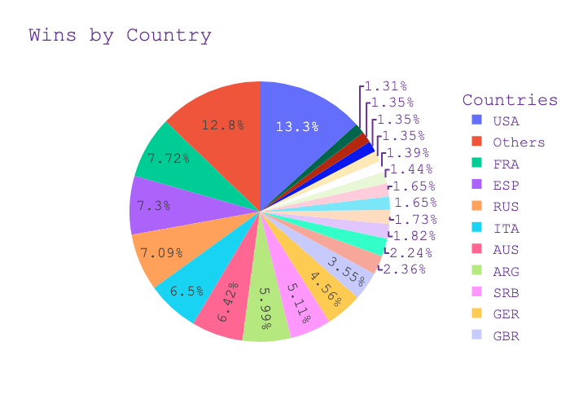

```python
# visualising the above data
fig = px.pie(x, values='count', names='winner_ioc', title='Wins by Country')
fig.update_layout(
    title="Wins by Country",
    legend_title="Countries",
    font=dict(
        family="Courier New, monospace",
        size=18,
        color="RebeccaPurple"
    )
)
fig.show()
```

#### Inference

From the above analysis we can infer that among all the countries which are mentioned in the dataset ,

- The Others legend which is mentioned in the grpah includes countries which have victories less than 30 .
- USA has the most number fo wins . Followed by France and Spain respectively.

#### (2) Top 15 Players in ATP with number of wins

```python
## Players with most number of wins
x=df['winner_name'].value_counts().reset_index().rename(columns={"index":"Player_name",0:"count"})
x
```

|  | winner_name | count |
| --- | --- | --- |
| 0 | Carlos Alcaraz | 58 |
| 1 | Daniil Medvedev | 56 |
| 2 | Taylor Fritz | 49 |
| 3 | Jannik Sinner | 46 |
| 4 | Novak Djokovic | 45 |
| ... | ... | ... |
| 251 | Jan Choinski | 1 |
| 252 | Harold Mayot | 1 |
| 253 | Giulio Zeppieri | 1 |
| 254 | Lucas Pouille | 1 |
| 255 | Menelaos Efstathiou | 1 |

256 rows × 2 columns

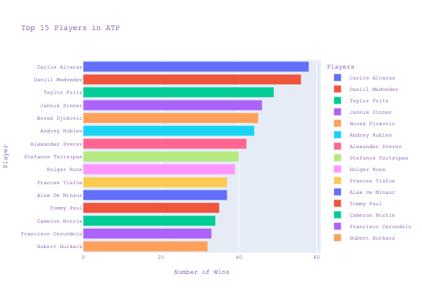

```python
## visualization of the top 15 players from the above data
fig = px.bar(x.head(15),x='count', y='winner_name', orientation='h',title='Top Tennis Players by Number of Wins',color='winner_name')
fig.update_layout(
    title="Top 15 Players in ATP",
    xaxis_title='Number of Wins', yaxis_title='Player',
    legend_title="Players",
    font=dict(
        family="Courier New, monospace",
        size=9,
        color="RebeccaPurple"
    )
)
fig.show()
```

#### Inference

Out of all the professianl tennis players list , the top 15 players with the maximum number of wins are depicted in the above graph.

Carlos Alcaraz has the maximum no of wins and stands on top of the player list.

### (3) Top 5 Countries in all the surfaces

```python
## Grouping the countries with respect to the surface
a=df[['surface','winner_ioc']]
x1 =a.groupby('surface')
```

```python
## saving the data of each surface seperately
hard_surface = pd.DataFrame(x1.get_group('Hard').value_counts().head().reset_index())
clay_surface = pd.DataFrame(x1.get_group('Clay').value_counts().head().reset_index())
grass_surface = pd.DataFrame(x1.get_group('Grass').value_counts().head().reset_index())
hard_surface
```

|  | surface | winner_ioc | count |
| --- | --- | --- | --- |
| 0 | Hard | USA | 220 |
| 1 | Hard | FRA | 102 |
| 2 | Hard | AUS | 89 |
| 3 | Hard | RUS | 81 |
| 4 | Hard | ITA | 61 |

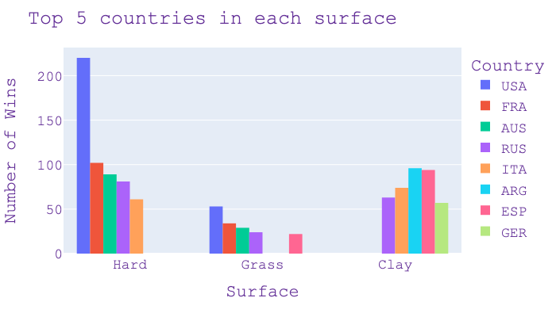

```python
## concatinating the above data into a single data Frame
surface_dataframe = pd.concat([hard_surface,clay_surface,grass_surface])
## Visualising the Top 5 countries in each surface
fig = px.histogram(surface_dataframe, x="surface", y='count',
             color='winner_ioc', barmode='group',
             height=400)
fig.update_layout(
    title=" Top 5 countries in each surface",
    xaxis_title="Surface",
    yaxis_title="Number of Wins",
    legend_title="Country",
    font=dict(
        family="Courier New, monospace",
        size=18,
        color="RebeccaPurple"
    )
)
fig.show()
```

#### Inference

As per the Dataset , the surfaces are classified into three types **HARD, GRASS , CLAY**. The countires which have perfomed well in above mentioned surfaces are illustrated.

- From the above graph, we see that Russia is performing well in all the three surfaces.
- Additionally USA tops in Hard Surface and Grass Surfaces while Argentina is found to perfrom well in Clay.

#### (4) Determining the `Correlation` to examine the relationship

```python
## Finding the correlation between number of first serves IN vs number of first serves Won
print(df["w_1stIn"].corr(df["w_1stWon"]))
x = df["w_1stIn"]
y = df["w_1stWon"]
```

```
0.9635868103962056
```

The correlation value is 0.9635 , which strongly states that the two attributes are highly dependent on each other.

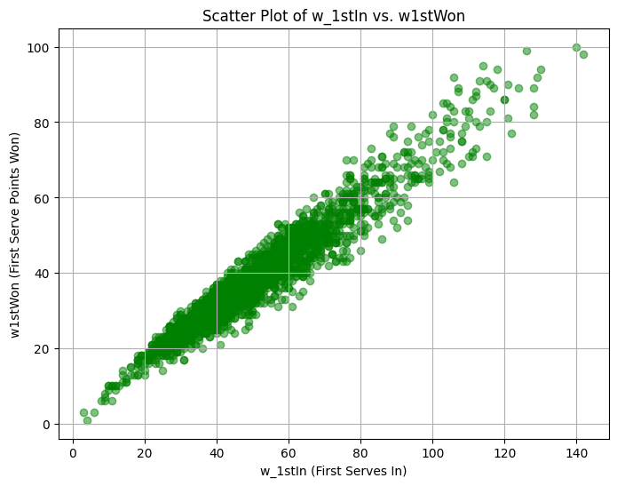

```python
## Plotting a graph to check the
plt.figure(figsize=(8, 6))
plt.scatter(x, y, alpha=0.5,color='green')
plt.title("Scatter Plot of w_1stIn vs. w1stWon")
plt.xlabel("w_1stIn (First Serves In)")
plt.ylabel("w1stWon (First Serve Points Won)")
plt.grid(True)
plt.show()
```

```python
dataf = df[['winner_ht','w_ace','w_1stWon','w_2ndWon','w_SvGms','w_bpSaved','w_bpFaced','l_ace','l_df','l_svpt','l_1stIn','l_1stWon','l_2ndWon','l_SvGms','l_bpSaved','l_bpFaced']]

dataf = dataf.dropna()
dataf
```

|  | winner_ht | w_ace | w_1stWon | w_2ndWon | w_SvGms | w_bpSaved | w_bpFaced | l_ace | l_df | l_svpt | l_1stIn | l_1stWon | l_2ndWon | l_SvGms | l_bpSaved | l_bpFaced |
| --- | --- | --- | --- | --- | --- | --- | --- | --- | --- | --- | --- | --- | --- | --- | --- | --- |
| 0 | 193.0 | 15.0 | 45.0 | 16.0 | 12.0 | 0.0 | 0.0 | 7.0 | 2.0 | 97.0 | 62.0 | 47.0 | 15.0 | 12.0 | 9.0 | 9.0 |
| 1 | 188.0 | 3.0 | 15.0 | 3.0 | 4.0 | 3.0 | 3.0 | 0.0 | 0.0 | 21.0 | 12.0 | 8.0 | 3.0 | 4.0 | 1.0 | 3.0 |
| 2 | 193.0 | 11.0 | 44.0 | 19.0 | 12.0 | 4.0 | 4.0 | 17.0 | 1.0 | 82.0 | 62.0 | 51.0 | 7.0 | 12.0 | 2.0 | 2.0 |
| 3 | 188.0 | 5.0 | 31.0 | 11.0 | 9.0 | 5.0 | 5.0 | 3.0 | 3.0 | 68.0 | 41.0 | 26.0 | 12.0 | 9.0 | 6.0 | 9.0 |
| 4 | 193.0 | 9.0 | 43.0 | 28.0 | 16.0 | 1.0 | 2.0 | 7.0 | 2.0 | 89.0 | 58.0 | 48.0 | 18.0 | 16.0 | 1.0 | 2.0 |
| ... | ... | ... | ... | ... | ... | ... | ... | ... | ... | ... | ... | ... | ... | ... | ... | ... |
| 2267 | 198.0 | 8.0 | 41.0 | 13.0 | 14.0 | 8.0 | 13.0 | 4.0 | 5.0 | 98.0 | 59.0 | 38.0 | 11.0 | 15.0 | 10.0 | 19.0 |
| 2269 | 188.0 | 7.0 | 39.0 | 21.0 | 14.0 | 10.0 | 12.0 | 8.0 | 2.0 | 89.0 | 49.0 | 36.0 | 11.0 | 13.0 | 3.0 | 9.0 |
| 2270 | 198.0 | 9.0 | 68.0 | 23.0 | 20.0 | 8.0 | 9.0 | 0.0 | 0.0 | 133.0 | 93.0 | 64.0 | 19.0 | 18.0 | 4.0 | 7.0 |
| 2271 | 188.0 | 5.0 | 56.0 | 11.0 | 16.0 | 4.0 | 6.0 | 5.0 | 5.0 | 102.0 | 72.0 | 43.0 | 14.0 | 14.0 | 9.0 | 14.0 |
| 2272 | 188.0 | 4.0 | 48.0 | 27.0 | 16.0 | 2.0 | 3.0 | 6.0 | 6.0 | 106.0 | 69.0 | 49.0 | 14.0 | 15.0 | 3.0 | 6.0 |

2155 rows × 16 columns

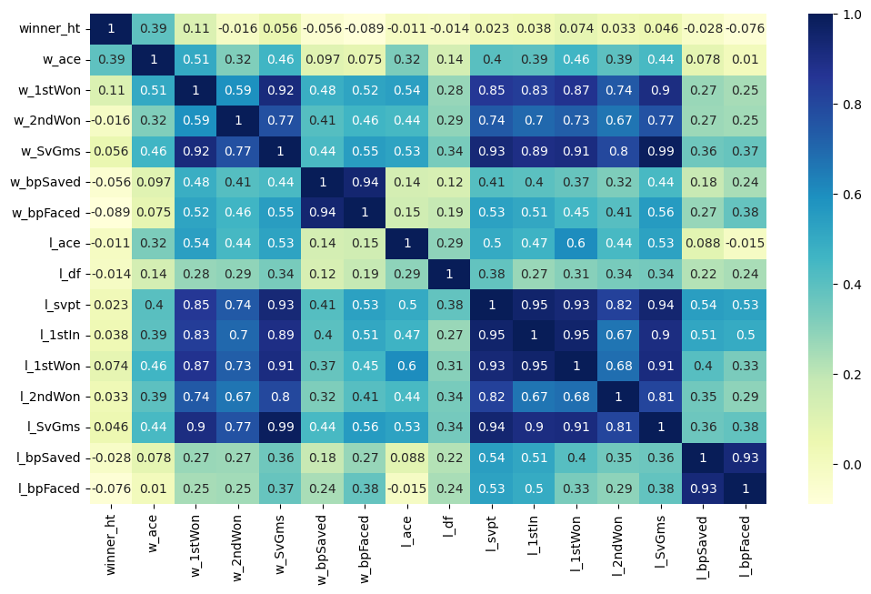

```python
plt.figure(figsize=(12, 7))
dataplot = sns.heatmap(dataf.corr(), cmap="YlGnBu", annot=True)
```

The deeper hues have higher correlation values than the lighter shades, which have a weaker relationship with the associated traits, according to the correlation matrix of all the attributes given above.

#### Victory anlaysis of players with respect to their height

```python
## Grouping by surface with winner height and loser height
a1 =df[['surface','winner_ht', 'loser_ht']]
ps =a1.groupby('surface')
```

```python
## Loading the group to seperate Dataset
hard_surface = pd.DataFrame(ps.get_group('Hard').reset_index())
clay_surface = pd.DataFrame(ps.get_group('Clay').reset_index())
grass_surface = pd.DataFrame(ps.get_group('Grass').reset_index())
hard_surface
```

|  | index | surface | winner_ht | loser_ht |
| --- | --- | --- | --- | --- |
| 0 | 0 | Hard | 193.0 | 196.0 |
| 1 | 1 | Hard | 188.0 | 185.0 |
| 2 | 2 | Hard | 193.0 | 196.0 |
| 3 | 3 | Hard | 188.0 | 183.0 |
| 4 | 4 | Hard | 193.0 | 196.0 |
| ... | ... | ... | ... | ... |
| 1162 | 2364 | Hard | NaN | NaN |
| 1163 | 2365 | Hard | 185.0 | NaN |
| 1164 | 2366 | Hard | 180.0 | NaN |
| 1165 | 2367 | Hard | NaN | 188.0 |
| 1166 | 2368 | Hard | 180.0 | 185.0 |

1167 rows × 4 columns

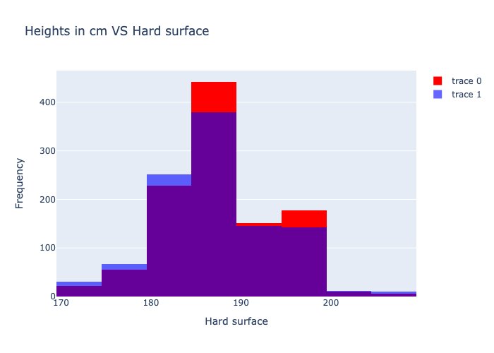

```python
## visualisation of players height vs Hard surface
fig = go.Figure()

fig.add_trace(
    go.Histogram(
         x=hard_surface['winner_ht'],
        marker=dict(color='red'),
         nbinsx=10,
    )
)

fig.add_trace(
    go.Histogram(
        x=hard_surface['loser_ht'],
        marker_color='blue',
         nbinsx=10,
         opacity=0.6
    )
)

fig.update_layout(
    title='Heights in cm VS Hard surface',
    xaxis=dict(title='Hard surface'),
    yaxis=dict(title='Frequency'),
    barmode='overlay',
    bargap=0
)

fig.show()
```

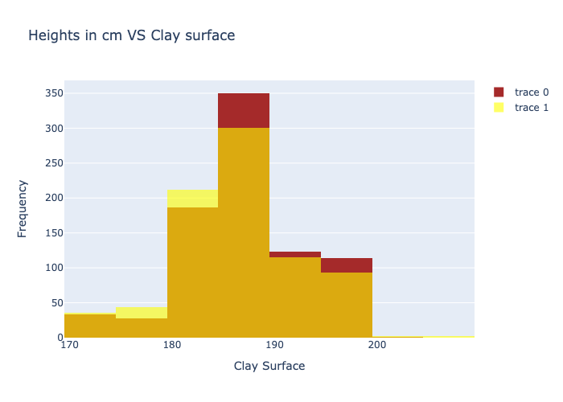

```python
## visualisation of players height vs Clay surface
fig = go.Figure()

fig.add_trace(
    go.Histogram(
         x=clay_surface['winner_ht'],
        marker=dict(color='brown'),
         nbinsx=10,
    )
)

fig.add_trace(
    go.Histogram(
        x=clay_surface['loser_ht'],
        marker_color='yellow',
         nbinsx=10,
         opacity=0.6
    )
)

fig.update_layout(
    title='Heights in cm VS Clay surface',
    xaxis=dict(title='Clay Surface'),
    yaxis=dict(title='Frequency'),
    barmode='overlay',
    bargap=0
)

fig.show()
```

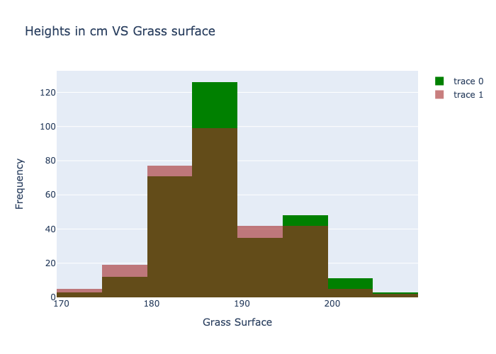

```python
## visualisation of players height vs Grass surface
fig = go.Figure()

fig.add_trace(
    go.Histogram(
         x=grass_surface['winner_ht'],
        marker=dict(color='green'),
         nbinsx=10,
    )
)

fig.add_trace(
    go.Histogram(
        x=grass_surface['loser_ht'],
        marker_color='brown',
         nbinsx=10,
         opacity=0.6
    )
)

fig.update_layout(
    title='Heights in cm VS Grass surface',
    xaxis=dict(title='Grass Surface'),
    yaxis=dict(title='Frequency'),
    barmode='overlay',  # Overlay the histograms
)

fig.show()
```

### Report Summary

In conclusion, we can learn a lot about the ATP matches that took place in 2023 from the facts provided here. These are just the fundamental analyses that we have provided in this document. With the aid of more advanced ML and Statistics models, we can extract much more detailed information from the data that may be used in useful ways.

### Contributers

ADITYA SRIRAM SESHADRI

NITHARSHAN COIMBATORE VENKATESAN

[KARTHICK BALAJE GOPALAKRISHNAN ELANGO](https://github.com/kb2326%27)